# Chapter 8: Selection bias

Abdullah Abdelaziz, BPharm, MSc

## Important disclaimer

- The term “Selection bias” can refer to different things depending on the discipline
  - Economists’ selection bias (selection on observables) is actually epidemiologists’ confounding bias.
  - Survey statisticians use selection bias term to sample selection from population, which can lead to biased conclusions in descriptive research.
- Epidemiologists excelled in conceptualizing and making the distinction between confounding and selection.
- It’s a good habit to make sure that your collaborators are on the same page regarding terminologies to avoid any confusions.

# General guidelines

## General guidelines

- Causal effects are linked to specific **populations**
- In many epidemiologic studies, you end up analyzing a cohort that’s different from your original cohort
  - Survival analysis: we analyze uncensored individuals (we don’t see the outcome in censored individuals).
  - Case-control studies: we analyze individuals who got the outcome and a sample of patients who did not the outcome.

## General guidelines

- The hope is that the estimate we get in this subset is the same as the one we would’ve had if we did the estimation on the original cohort.
- If this is not the case ➔ Selection bias
- In all the coming DAGs, selection is represented as a variable with a square around it.
- The square here does not mean statistical adjustment. It means that the analysis is done on one stratum of the selection variable.
  - DAGs are not just useful in helping identifying adjustment covariates. They can help in the design as well.

# Types of selection bias

## Selection bias under the null

- This type of selection bias can arise regardless of the true treatment effect being null or not.
- Conditioning on a collider (or a descendant of a collider) is necessary for this bias to happen.
- This is the topic of this book and Hernan’s famous paper in 2004 (Hernán, Hernández-Díaz, and Robins 2004)

## Selection bias off the null

- This type of selection bias **cannot** happen under the null.
- This type of selection bias **can** happen even without conditioning on colliders.

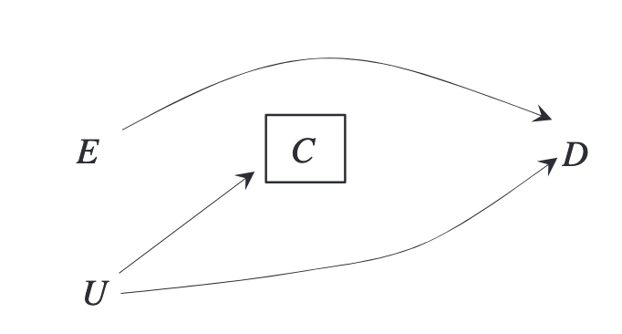

- This bias is not covered in the chapter.

# Selection bias in cross-sectional studies

## Example 1

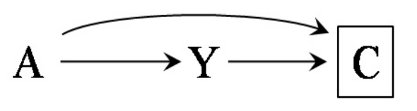

- $A$ : Treatment
- $Y$ : Fetal malformation
- $C$ : Live birth

  We don’t have $Y$ for dead fetuses, so we essentially **restricting our analysis to** living fetuses.

## Example 1

- Our regression will give us this quantity

$$\frac{Pr[Y = 1|A = 1, C = 0]}{ Pr[Y = 1|A = 0, C = 0]}$$

- Is this a valid estimate for our estimand?

  $$\frac{Pr[Y^{ a=1} = 1]}{Pr[Y^{ a=0} = 1]}$$

  The answer is no, because we have association transmitted through the path $A \rightarrow C \leftarrow Y$

## Example 2

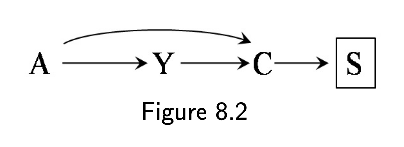

- $A$ : Treatment
- $Y$ : Fetal malformation
- $C$ : Live birth
- $S$: Parental grief

A descendant of a collider is as dangerous as the collider itself.

# Selection bias in cohort studies

Including randomized trials

## Example

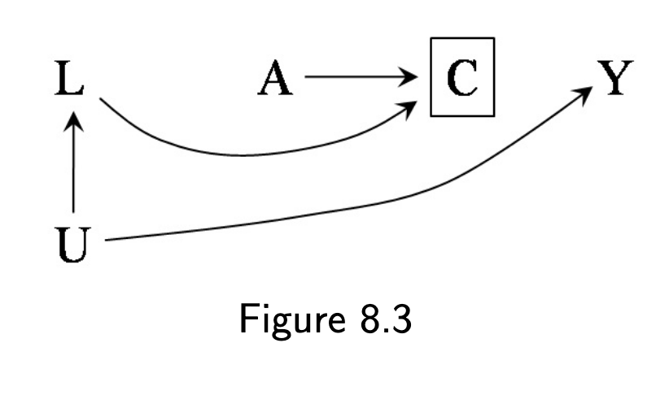

- $A$ : Antiretroviral treatment
- $Y$: Death
- $L$: Disease severity
- $U$: High level of immunosuppression
- $C$: Loss to follow-up

## Example

- Remember, $C$ is not a variable we put in a regression model. It’s a part of how your **analyzed data was formed**.
- In this example, $A$ can show favorable result not because it’s actually effective in reducing mortality, but because it caused sick people to leave the study. Although in reality, $A$ and $Y$ are not associated.
- The previous DAG is an example of selection bias due to **differential loss-to-follow-up** or **informative censoring.**

## Similar DAGs for differential loss-to-follow-up

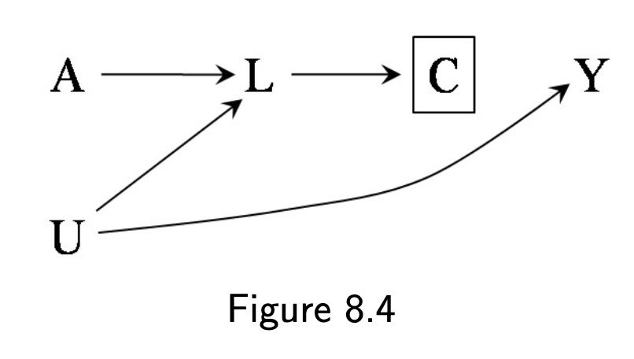

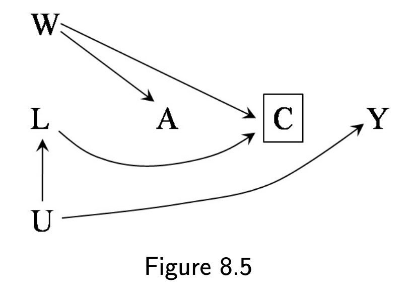

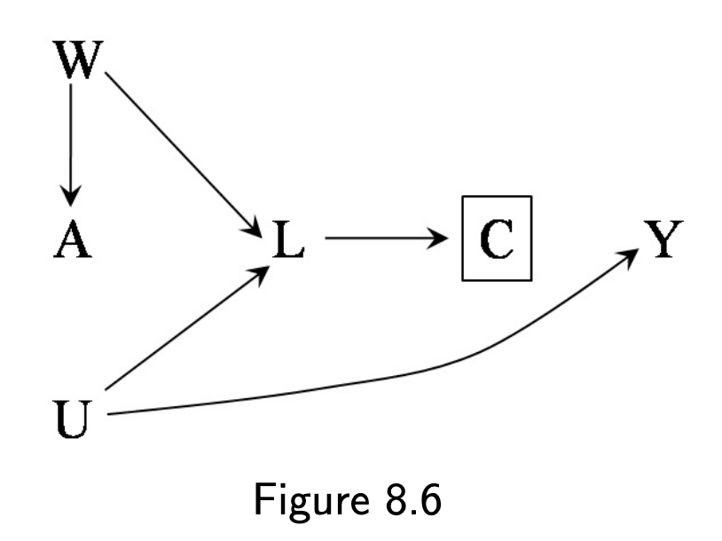